# A3: SPL Library Checkouts

### Introduction

The data displayed is from a library circulation dataset published by the Seattle Public Library. The specific dataset I chose to work with holds all items check out from January 2022 to January of 2023. I have decided to look at books created by authors Dr.Seuss, and Stephen King, and look at the trends in the number of books checked out that are written by these two authors. To be more precise, I am going to to calculate the sum checkouts for each month, as well as the average number of checkouts, and compare the sum checkouts for each month to the average, for each author. I will then compare each other’s sum checkouts per month, to each other. I decided to look at the data of these two authors, to compare the trends in checkouts of boks catered to kids, versus books catered to adults.

### Summary Information

This Seattle Public Library dataset has recorded 8402376 total checkouts in the year 2022. However, my data collection specifically involves books by Dr.Seuss and Stephen King. In terms of books written by Dr.Seuss, he has had a total of 8196 checkouts, and an average of 683 checkouts per month in the year 2022. The least number of checkouts per month, 564 occurred in month 7, and the most checkouts, 821, occurred in month 3, of the 2022 year. As for Stephen King, he has had a total of 16374 checkouts, and an average of 1364 checkouts per month in the year 2022. The least number of checkouts per month, 1012 occurred in month 4, and the most checkouts, 1729, occurred in month 10, of the 2022 year.

### The Dataset

Who collected/published the data?

- The data was published by The Seatte Public Library.

What are the parameters of the data (dates, number of checkouts, kinds of books, etc.)?

- This dataset has 9196991, holds data from 2022-1-01 to 2023-1-01, and includes records of both paper, ebook, and audio book types.

How was the data collected or generated?

- The data is collected/updated monthly on or about the 6th day of the month with the previous month’s data.

Why was the data collected?

- The data was collected to keep track of checkouts at The Seattle Public Library, tracking the creator, publisher, isbn, checkout month and year, and more features.

What, if any, ethical questions do you need to consider when working with this data?

- One question is whether names and personal information about those who checkout these books are able to be found/tracked by anyone, resulting in privacy issues.

What are possible limitations or problems with this data? (at least 200 words)

- One limitation is the checkout date, specifically, the record of a specific day of the month. If the Seattle Public Library wanted to specifically see when a book was checked out within a certain month, or someone who checked out a book from the Seattle Public Library wanted to remember when they checked out their book, they would not be able to find such information, as they only have records on the checkout month and year.
- Another limitation comes from the blank subject headings for older checkouts. Because historic checkouts for were combined with current Horizon record details in December 2016, if a Horizon record for a book was not present as of December 2016, the subject heading would be left blank (as stated in the “Checkouts by Title FAQ”). Because this data comes from multiple sources (to get current and historical data), the congregation of information may lead to misinformation (repeated records or no records for a title that should have records).
- Additionally, because this dataset only accounts for checkouts, renewals of physical items aren’t being recorded, therefore a book may seem to have been checked out for a shorter period than it actually was checked out for, leading to another “hole” in the records.

### Chart 1: Dr.Seuss Book Checkouts per Month in 2022

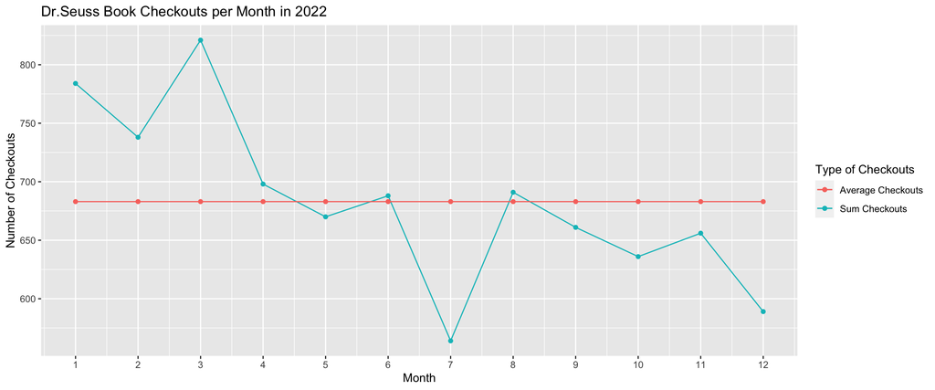

### Chart 2: Stephen King Book Checkouts per Month in 2022

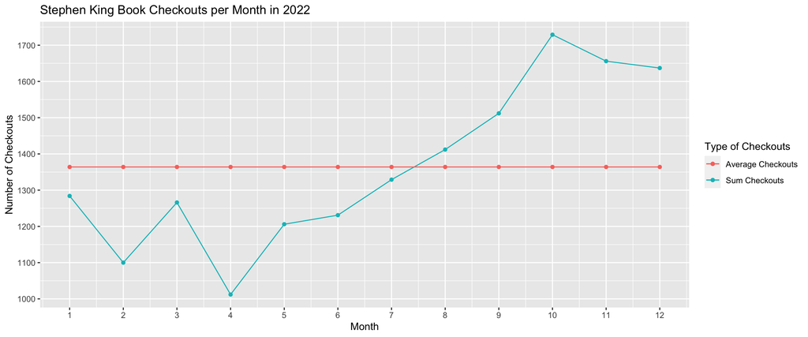

This second chart displays trends in checkouts of books created by Stephen King, because I wanted to also see a trend in books catered to adults (fiction, suspense, crime). With this chart, you can compare the checkouts per month in the year 2022, to the average number of Stephen King book checkouts. From this graph, you can see that the number of checkouts were below average in the first 7 months, but an increase in checkouts began soon after, and the number of checkouts was above average from months 8 to 11, and rose greatly in month 10. Unfortunately for King, there was a slight decrease in checkouts from months 11 and 12. However, overall, there was an increase in checkouts of Stephen King books in the year 2022.

### Chart 3: Dr.Seuss vs. Stephen King Checkouts in 2022

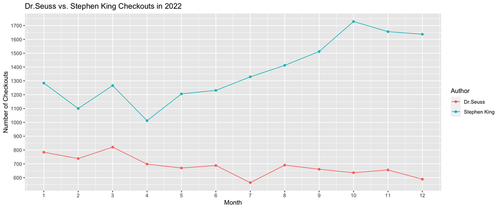